# R语言与机器学习（下）

## 9.8 主成分分析（PCA）降维

### 基本原理

**主成分分析（PCA）** 是一种线性降维方法，通过正交变换将高维数据投影到低维空间，保留尽可能多的方差。

**目标**：找到数据方差最大的方向（主成分）

$$\max_w \text{Var}(Xw) = \max_w w^T
\Sigma w$$

其中$\Sigma$是协方差矩阵。

```r
# PCA示例：基因表达数据降维
set.seed(42)

# 生成模拟基因表达数据（100个样本，50个基因）
n_samples <- 100
n_genes <- 50

# 创建具有分组结构的基因表达数据
gene_expr <- matrix(rnorm(n_samples * n_genes), nrow = n_samples, ncol = n_genes)

# 添加分组效应
gene_expr[1:50, 1:10] <- gene_expr[1:50, 1:10] + 2  # 第一组样本的前10个基因高表达
gene_expr[51:100, 11:20] <- gene_expr[51:100, 11:20] + 2  # 第二组样本的中间基因高表达

# 转换为数据框
gene_df <- as.data.frame(gene_expr)
colnames(gene_df) <- paste0("Gene_", 1:n_genes)

# 执行PCA
pca_result <- prcomp(gene_df, scale. = TRUE, center = TRUE)

# 查看主成分的方差贡献
var_explained <- pca_result$sdev^2 / sum(pca_result$sdev^2)
var_df <- data.frame(
  PC = paste0("PC", 1:10),
  Variance = var_explained[1:10] * 100,
  Cumulative = cumsum(var_explained[1:10]) * 100
)

print("前10个主成分的方差贡献：")
```

```
## [1] "前10个主成分的方差贡献："
```

```r
print(head(var_df, 10))
```

```
##      PC  Variance Cumulative
## 1   PC1 21.864839   21.86484
## 2   PC2  4.922180   26.78702
## 3   PC3  4.356587   31.14361
## 4   PC4  4.213363   35.35697
## 5   PC5  3.772029   39.12900
## 6   PC6  3.487178   42.61618
## 7   PC7  3.416547   46.03272
## 8   PC8  3.143081   49.17580
## 9   PC9  3.090488   52.26629
## 10 PC10  2.841843   55.10813
```

### 可视化PCA结果

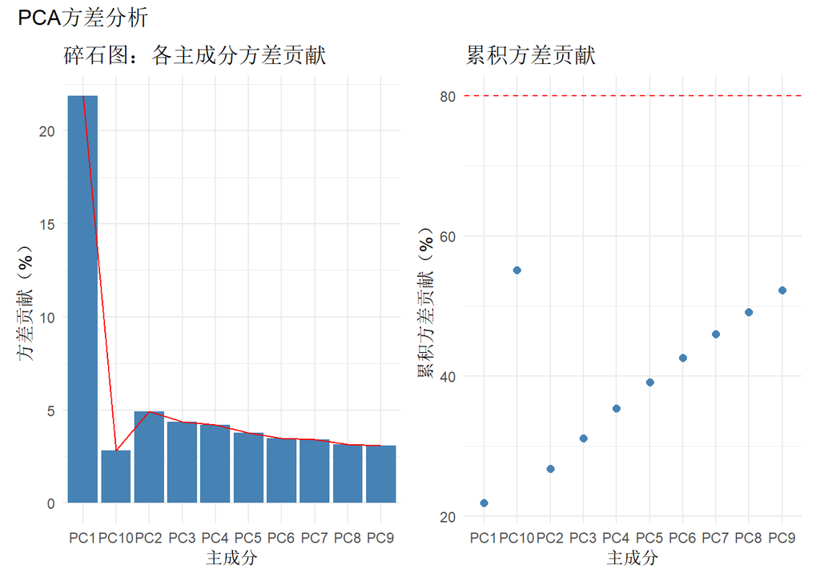

```r
# 碎石图：方差贡献
p1 <- ggplot2::ggplot(var_df, ggplot2::aes(x = PC, y = Variance)) +
  ggplot2::geom_bar(stat = "identity", fill = "steelblue") +
  ggplot2::geom_line(ggplot2::aes(group = 1), color = "red") +
  ggplot2::labs(
    title = "碎石图：各主成分方差贡献",
    x = "主成分", y = "方差贡献（%）"
  ) +
  ggplot2::theme_minimal()

# 累积方差贡献
p2 <- ggplot2::ggplot(var_df, ggplot2::aes(x = PC, y = Cumulative)) +
  ggplot2::geom_line(color = "steelblue", linewidth = 1) +
  ggplot2::geom_point(color = "steelblue", size = 2) +
  ggplot2::geom_hline(yintercept = 80, linetype = "dashed", color = "red") +
  ggplot2::labs(
    title = "累积方差贡献",
    x = "主成分", y = "累积方差贡献（%）"
  ) +
  ggplot2::theme_minimal()

p1 + p2 + patchwork::plot_annotation(
  title = "PCA方差分析"
)
```

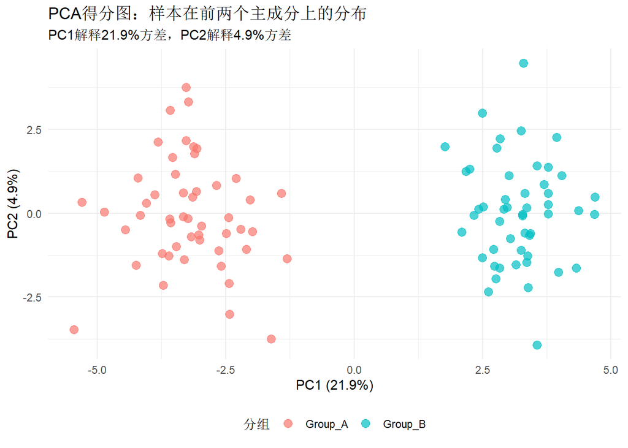

```r
# 添加分组信息
gene_df$group <- factor(rep(c("Group_A", "Group_B"), each = 50))

# 创建PCA得分数据框
pca_scores <- as.data.frame(pca_result$x[, 1:2])
pca_scores$group <- gene_df$group

# 绘制PCA得分图
ggplot2::ggplot(pca_scores, ggplot2::aes(x = PC1, y = PC2)) +
  ggplot2::geom_point(ggplot2::aes(color = group), size = 3, alpha = 0.7) +
  ggplot2::labs(
    title = "PCA得分图：样本在前两个主成分上的分布",
    subtitle = paste0("PC1解释", round(var_explained[1] * 100, 1),
                      "%方差，PC2解释", round(var_explained[2] * 100, 1), "%方差"),
    x = paste0("PC1 (", round(var_explained[1] * 100, 1), "%)"),
    y = paste0("PC2 (", round(var_explained[2] * 100, 1), "%)"),
    color = "分组"
  ) +
  ggplot2::theme_minimal() +
  ggplot2::theme(legend.position = "bottom")
```

### 意义与使用场景

**核心意义**：PCA是最常用的降维方法，能够减少数据维度、去除噪声、可视化高维数据。

**举例**：基因表达谱可视化

**为什么这种数据适合用PCA？**

基因表达数据通常有数千个基因（高维），但样本数相对较少。PCA可以将高维数据降维到2-3维，便于可视化和发现样本分组模式。

**研究目的是什么？**

1. 数据可视化：将高维数据投影到2D/3D空间
2. 降噪：去除方差较小的成分（通常是噪声）
3. 特征提取：用主成分作为新特征

**可能得到什么样的结果？**

PCA可能揭示样本在PC1-PC2平面上的自然分组，不同疾病类型的患者可能形成明显的簇。

**需要注意什么？**

PCA是线性方法，对于非线性结构可能效果不好。主成分的解释性可能较差，需要结合载荷矩阵分析。

## 9.9 流形学习：t-SNE与UMAP

### t-SNE原理

**t-SNE（t-Distributed Stochastic Neighbor Embedding）** 是一种非线性降维方法，特别适合高维数据的可视化。

**核心思想**： 1. 在高维空间计算样本间的相似度（高斯分布） 2. 在低维空间计算样本间的相似度（t分布） 3. 最小化两个相似度分布的KL散度

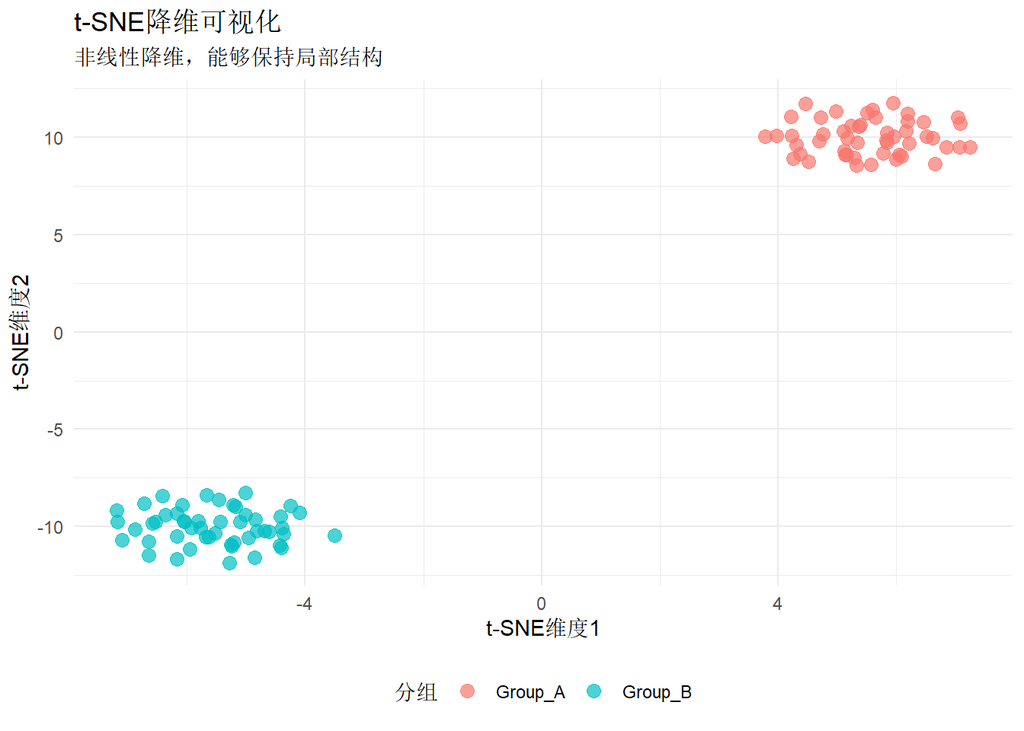

```r
# t-SNE示例
set.seed(42)

# 使用Rtsne包进行t-SNE降维
library(Rtsne)

# 对基因表达数据进行t-SNE
tsne_result <- Rtsne::Rtsne(gene_df[, 1:n_genes],
                             dims = 2,
                             perplexity = 30,
                             verbose = FALSE)

# 创建结果数据框
tsne_df <- as.data.frame(tsne_result$Y)
colnames(tsne_df) <- c("tSNE1", "tSNE2")
tsne_df$group <- gene_df$group

# 可视化t-SNE结果
ggplot2::ggplot(tsne_df, ggplot2::aes(x = tSNE1, y = tSNE2)) +
  ggplot2::geom_point(ggplot2::aes(color = group), size = 3, alpha = 0.7) +
  ggplot2::labs(
    title = "t-SNE降维可视化",
    subtitle = "非线性降维，能够保持局部结构",
    x = "t-SNE维度1", y = "t-SNE维度2", color = "分组"
  ) +
  ggplot2::theme_minimal() +
  ggplot2::theme(legend.position = "bottom")
```

### UMAP原理

**UMAP（Uniform Manifold Approximation and Projection）** 是另一种流行的非线性降维方法，比t-SNE更快，且能更好地保持全局结构。

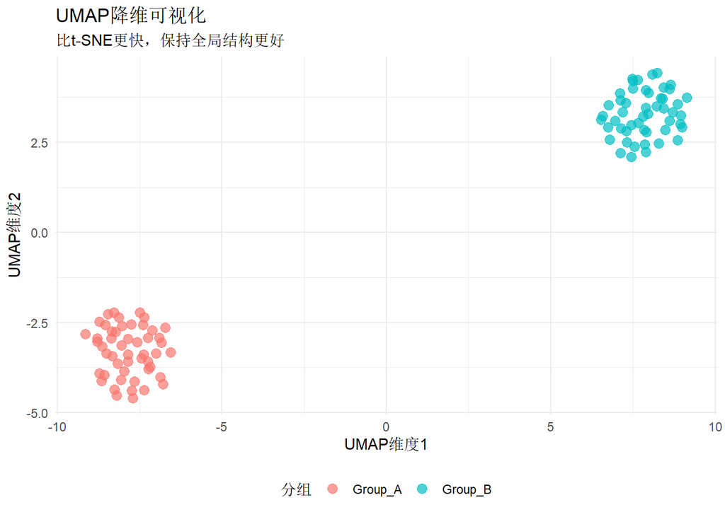

```r
# UMAP示例
library(umap)

# 执行UMAP降维
umap_result <- umap::umap(gene_df[, 1:n_genes])

# 创建结果数据框
umap_df <- as.data.frame(umap_result$layout)
colnames(umap_df) <- c("UMAP1", "UMAP2")
umap_df$group <- gene_df$group

# 可视化UMAP结果
ggplot2::ggplot(umap_df, ggplot2::aes(x = UMAP1, y = UMAP2)) +
  ggplot2::geom_point(ggplot2::aes(color = group), size = 3, alpha = 0.7) +
  ggplot2::labs(
    title = "UMAP降维可视化",
    subtitle = "比t-SNE更快，保持全局结构更好",
    x = "UMAP维度1", y = "UMAP维度2", color = "分组"
  ) +
  ggplot2::theme_minimal() +
  ggplot2::theme(legend.position = "bottom")
```

### PCA vs t-SNE vs UMAP对比

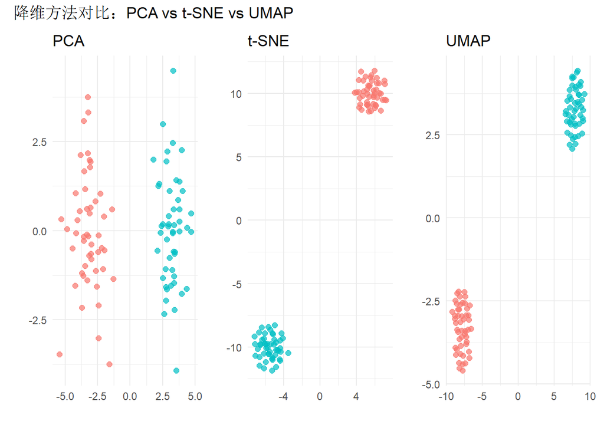

```r
# 三种方法的对比可视化
p_pca <- ggplot2::ggplot(pca_scores, ggplot2::aes(x = PC1, y = PC2)) +
  ggplot2::geom_point(ggplot2::aes(color = group), size = 2, alpha = 0.7) +
  ggplot2::labs(title = "PCA", x = "", y = "") +
  ggplot2::theme_minimal() +
  ggplot2::theme(legend.position = "none")

p_tsne <- ggplot2::ggplot(tsne_df, ggplot2::aes(x = tSNE1, y = tSNE2)) +
  ggplot2::geom_point(ggplot2::aes(color = group), size = 2, alpha = 0.7) +
  ggplot2::labs(title = "t-SNE", x = "", y = "") +
  ggplot2::theme_minimal() +
  ggplot2::theme(legend.position = "none")

p_umap <- ggplot2::ggplot(umap_df, ggplot2::aes(x = UMAP1, y = UMAP2)) +
  ggplot2::geom_point(ggplot2::aes(color = group), size = 2, alpha = 0.7) +
  ggplot2::labs(title = "UMAP", x = "", y = "") +
  ggplot2::theme_minimal() +
  ggplot2::theme(legend.position = "none")

p_pca + p_tsne + p_umap + patchwork::plot_annotation(
  title = "降维方法对比：PCA vs t-SNE vs UMAP"
)
```

### 意义与使用场景

**核心意义**：非线性降维方法能够揭示高维数据的复杂结构，是数据探索和可视化的有力工具。

**举例**：单细胞RNA测序数据分析

**为什么这种数据适合用t-SNE/UMAP？**

单细胞RNA测序数据通常有数千个基因，但每个细胞只表达其中一部分。数据具有高度非线性的结构，传统线性方法难以捕捉。t-SNE和UMAP能够揭示细胞亚群和分化轨迹。

**研究目的是什么？**

1. 细胞类型识别：发现不同的细胞亚群
2. 分化轨迹推断：理解细胞发育过程
3. 异质性分析：发现稀有细胞类型

**可能得到什么样的结果？**

t-SNE/UMAP图可能显示多个明显的细胞簇，对应不同的细胞类型或状态。

**需要注意什么？**

t-SNE和UMAP的结果受参数影响较大，不同运行可能得到不同结果。距离和簇大小在图中可能不反映真实情况，需要结合其他方法验证。

## 9.10 自编码器降维概念

### 基本原理

**自编码器（Autoencoder）** 是一种神经网络架构，用于学习数据的有效压缩表示：

**结构**： - **编码器**：将输入压缩到低维潜在空间 - **解码器**：从潜在表示重建输入

**目标**：最小化重建误差 $\|x - \hat{x}\|^2$

```
输入层 → 编码层 → 潜在层（低维） → 解码层 → 输出层
```

### 与传统降维方法的比较

| 方法 | 类型 | 优点 | 缺点 |
| --- | --- | --- | --- |
| PCA | 线性 | 快速、可解释 | 只能捕捉线性结构 |
| t-SNE | 非线性 | 可视化效果好 | 计算慢、不可逆 |
| UMAP | 非线性 | 快速、保持全局结构 | 参数敏感 |
| 自编码器 | 非线性 | 可学习复杂特征 | 需要大量数据、黑箱 |

### 医学应用场景

自编码器在医学领域的应用包括：

1. **医学图像压缩**：压缩MRI、CT图像，减少存储空间
2. **异常检测**：重建误差大的样本可能是异常
3. **特征学习**：学习医学图像的深层特征用于分类

**注意**：自编码器涉及深度学习，本教程仅介绍概念，具体实现可参考深度学习框架如Keras、PyTorch。

## 9.11 异常检测方法

### 异常检测概述

**异常检测（Anomaly Detection）** 识别与大多数数据显著不同的样本。在医学领域，异常可能对应疾病、误诊、数据错误等。

### 孤立森林（Isolation Forest）

**原理**：异常点更容易被孤立（需要更少的分割即可分离）

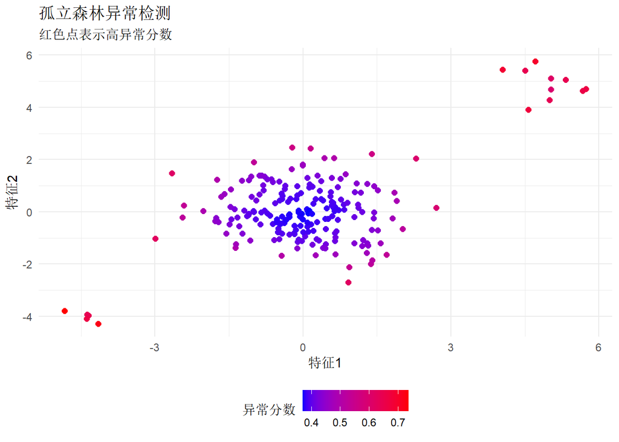

```r
# 孤立森林示例
set.seed(42)

# 生成正常数据和异常数据
normal_data <- data.frame(
  feature1 = rnorm(200, mean = 0, sd = 1),
  feature2 = rnorm(200, mean = 0, sd = 1),
  type = "正常"
)

# 添加异常点
anomaly_data <- data.frame(
  feature1 = c(rnorm(10, mean = 5, sd = 0.5), rnorm(5, mean = -4, sd = 0.5)),
  feature2 = c(rnorm(10, mean = 5, sd = 0.5), rnorm(5, mean = -4, sd = 0.5)),
  type = "异常"
)

# 合并数据
all_data <- rbind(normal_data, anomaly_data)

# 使用isotree包实现孤立森林
library(isotree)
iso_forest <- isotree::isolation.forest(all_data[, c("feature1", "feature2")])

# 预测异常分数
all_data$anomaly_score <- predict(iso_forest, all_data[, c("feature1", "feature2")])

# 可视化异常分数
ggplot2::ggplot(all_data, ggplot2::aes(x = feature1, y = feature2)) +
  ggplot2::geom_point(ggplot2::aes(color = anomaly_score), size = 2) +
  ggplot2::scale_color_gradient(low = "blue", high = "red") +
  ggplot2::labs(
    title = "孤立森林异常检测",
    subtitle = "红色点表示高异常分数",
    x = "特征1", y = "特征2", color = "异常分数"
  ) +
  ggplot2::theme_minimal() +
  ggplot2::theme(legend.position = "bottom")
```

### 局部异常因子（LOF）

**原理**：比较样本的局部密度与邻居的局部密度

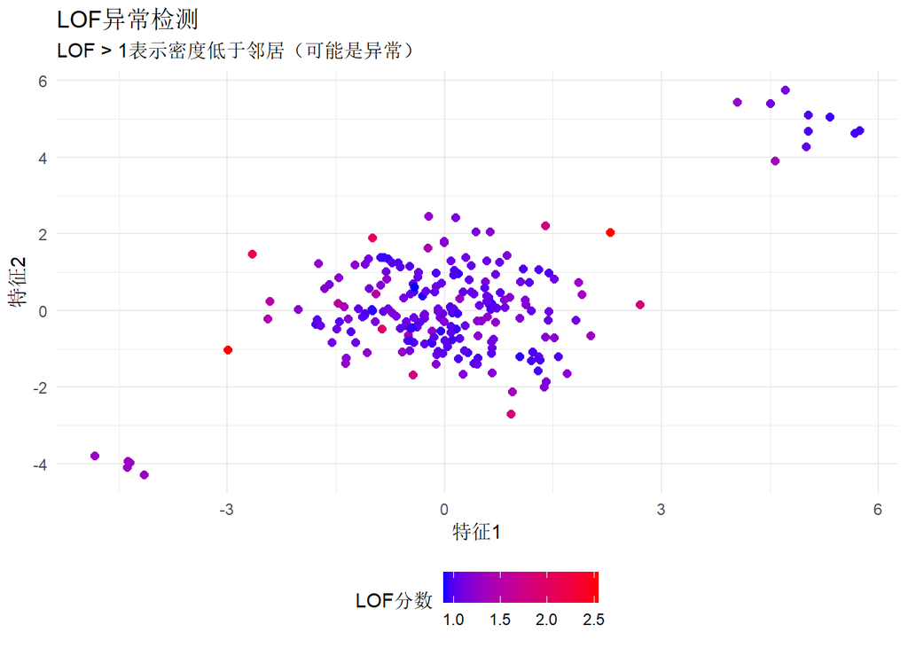

```r
# LOF异常检测
library(dbscan)

# 计算LOF分数
lof_scores <- dbscan::lof(all_data[, c("feature1", "feature2")], k = 5)

# 添加LOF分数到数据框
all_data$lof_score <- lof_scores

# 可视化LOF分数
ggplot2::ggplot(all_data, ggplot2::aes(x = feature1, y = feature2)) +
  ggplot2::geom_point(ggplot2::aes(color = lof_score), size = 2) +
  ggplot2::scale_color_gradient(low = "blue", high = "red") +
  ggplot2::labs(
    title = "LOF异常检测",
    subtitle = "LOF > 1表示密度低于邻居（可能是异常）",
    x = "特征1", y = "特征2", color = "LOF分数"
  ) +
  ggplot2::theme_minimal() +
  ggplot2::theme(legend.position = "bottom")
```

### 单类SVM

**原理**：学习正常数据的边界，边界外的点为异常

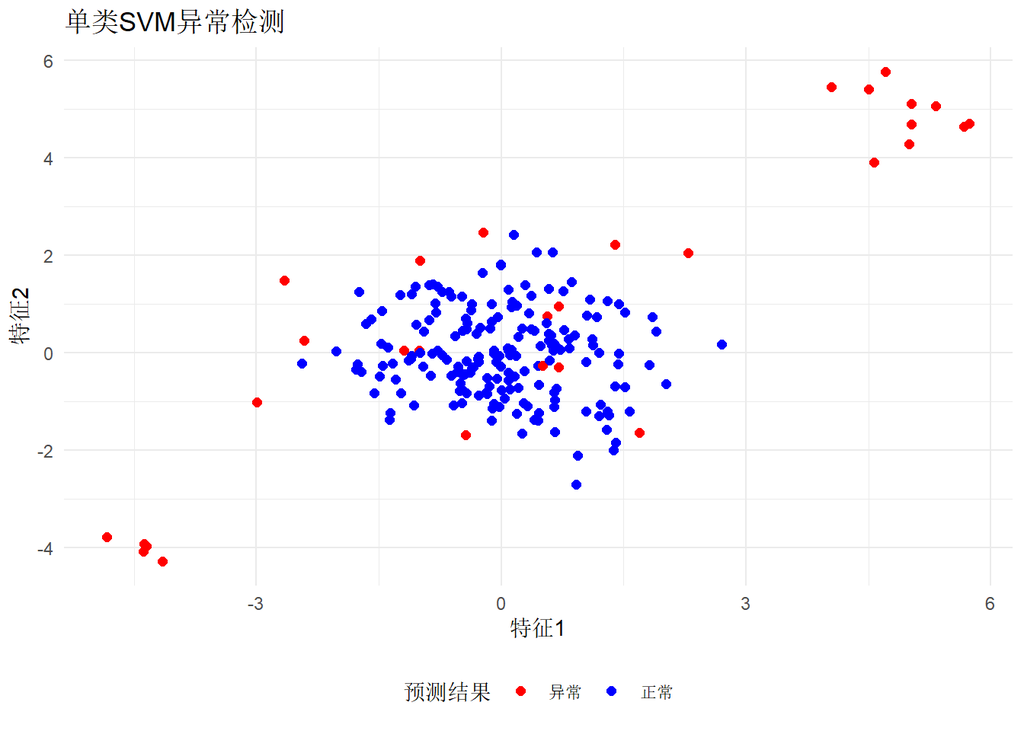

```r
# 单类SVM示例
library(e1071)

# 训练单类SVM（只使用正常数据）
ocsvm_model <- e1071::svm(
  x = as.matrix(normal_data[, c("feature1", "feature2")]),
  type = "one-classification",
  nu = 0.05,  # 预期异常比例
  kernel = "radial"
)

# 预测
all_data$ocsvm_pred <- predict(ocsvm_model, all_data[, c("feature1", "feature2")])

# 可视化
ggplot2::ggplot(all_data, ggplot2::aes(x = feature1, y = feature2)) +
  ggplot2::geom_point(ggplot2::aes(color = ocsvm_pred), size = 2) +
  ggplot2::scale_color_manual(values = c("FALSE" = "red", "TRUE" = "blue"),
                               labels = c("FALSE" = "异常", "TRUE" = "正常")) +
  ggplot2::labs(
    title = "单类SVM异常检测",
    x = "特征1", y = "特征2", color = "预测结果"
  ) +
  ggplot2::theme_minimal() +
  ggplot2::theme(legend.position = "bottom")
```

### 意义与使用场景

**核心意义**：异常检测能够自动识别异常样本，在医学领域有重要应用。

**举例**：医疗数据质量控制

**为什么需要异常检测？**

医疗数据可能存在录入错误、设备故障、极端病例等异常情况。异常检测可以自动识别这些情况，提高数据质量。

**研究目的是什么？**

1. 数据清洗：识别和修正数据录入错误
2. 设备监控：检测医疗设备异常
3. 疑难病例发现：识别需要特别关注的病例

**可能得到什么样的结果？**

异常检测可能发现某些患者的检验指标异常偏离正常范围，需要进一步核实。

**需要注意什么？**

异常不一定是错误，可能是真实的极端情况。需要结合领域知识判断异常的性质。

# 第十章 关联规则与模式挖掘

## 10.1 关联规则基本概念

### 什么是关联规则？

**关联规则（Association Rules）** 发现数据项之间的有趣关联关系，最著名的例子是”啤酒与尿布”的购物篮分析。

**基本概念**：

[output not shown]

### 三个核心指标

**支持度（Support）**：

$$\text{Support}(A \rightarrow B) =
\frac{|A \cap B|}{|D|}$$

表示A和B同时出现的频率。

**置信度（Confidence）**：

$$\text{Confidence}(A \rightarrow B) =
\frac{\text{Support}(A \cup B)}{\text{Support}(A)}$$

表示在A出现的条件下B出现的概率。

**提升度（Lift）**：

$$\text{Lift}(A \rightarrow B) =
\frac{\text{Confidence}(A \rightarrow
B)}{\text{Support}(B)}$$

- Lift > 1：A和B正相关
- Lift = 1：A和B独立
- Lift < 1：A和B负相关

```r
# 关联规则示例：医学共病分析
# 创建模拟的疾病共病数据

set.seed(42)

# 假设有1000个患者的诊断记录
n_patients <- 1000

# 创建疾病诊断矩阵（患者 × 疾病）
diseases <- c("高血压", "糖尿病", "冠心病", "高血脂", "肥胖", "肾病")

# 生成模拟数据：某些疾病倾向于同时出现
diagnosis_data <- matrix(0, nrow = n_patients, ncol = length(diseases))
colnames(diagnosis_data) <- diseases

# 模拟疾病关联
for (i in 1:n_patients) {
  # 基础概率
  diagnosis_data[i, "高血压"] <- rbinom(1, 1, 0.3)
  diagnosis_data[i, "糖尿病"] <- rbinom(1, 1, 0.2)

  # 高血压患者更容易有冠心病
  if (diagnosis_data[i, "高血压"] == 1) {
    diagnosis_data[i, "冠心病"] <- rbinom(1, 1, 0.4)
  } else {
    diagnosis_data[i, "冠心病"] <- rbinom(1, 1, 0.1)
  }

  # 糖尿病患者更容易有肾病
  if (diagnosis_data[i, "糖尿病"] == 1) {
    diagnosis_data[i, "肾病"] <- rbinom(1, 1, 0.3)
  } else {
    diagnosis_data[i, "肾病"] <- rbinom(1, 1, 0.05)
  }

  # 其他疾病
  diagnosis_data[i, "高血脂"] <- rbinom(1, 1, 0.25)
  diagnosis_data[i, "肥胖"] <- rbinom(1, 1, 0.2)
}

# 转换为数据框
diagnosis_df <- as.data.frame(diagnosis_data)

# 查看数据结构
head(diagnosis_df)
```

```
##   高血压 糖尿病 冠心病 高血脂 肥胖 肾病
## 1      1      1      0      0    0    1
## 2      1      0      1      0    0    0
## 3      1      0      0      1    0    0
## 4      0      0      1      1    1    0
## 5      0      0      0      0    1    0
## 6      1      1      0      0    1    0
```

```r
# 计算各疾病的患病率（支持度）
disease_support <- colMeans(diagnosis_df)
print("各疾病患病率：")
```

```
## [1] "各疾病患病率："
```

```r
print(round(disease_support, 3))
```

```
## 高血压 糖尿病 冠心病 高血脂   肥胖   肾病
##  0.301  0.227  0.183  0.256  0.214  0.122
```

### 意义与使用场景

**核心意义**：关联规则帮助发现数据中的隐含模式，是数据挖掘的基础方法。

**举例**：疾病共病模式发现

**为什么这种数据适合用关联规则？**

疾病之间存在复杂的共病关系，某些疾病可能倾向于同时出现。关联规则可以发现这些隐含的共病模式，帮助医生理解疾病之间的关系。

**研究目的是什么？**

1. 发现共病模式：识别经常同时出现的疾病组合
2. 风险预警：发现某种疾病后，预警可能的并发症
3. 病理机制探索：为疾病关联机制研究提供线索

**可能得到什么样的结果？**

可能发现”高血压→冠心病”的强关联规则，提示高血压患者需要重点关注心血管健康。

**需要注意什么？**

关联关系不等于因果关系。发现的规则需要结合医学知识进行解释和验证。

## 10.2 Apriori算法

### 算法原理

**Apriori算法** 是最经典的关联规则挖掘算法，基于频繁项集的先验性质：

**核心思想**：如果某个项集是频繁的，那么它的所有子集也是频繁的。

**算法步骤**： 1. 扫描数据库，找出频繁1-项集（L1） 2. 由L1生成候选2-项集，找出频繁2-项集（L2） 3. 重复直到无法生成更大的频繁项集 4. 由频繁项集生成关联规则

```r
# 使用arules包进行关联规则挖掘
library(arules)

# 将数据转换为transactions格式
# 首先将数据转换为适合arules的格式

# 创建交易数据：每个患者的疾病列表
transactions_list <- apply(diagnosis_df, 1, function(x) {
  diseases[x == 1]
})

# 转换为transactions对象
trans <- as(transactions_list, "transactions")

# 查看事务摘要
summary(trans)
```

```
## transactions as itemMatrix in sparse format with
##  1000 rows (elements/itemsets/transactions) and
##  6 columns (items) and a density of 0.2171667
##
## most frequent items:
##  高血压  高血脂  糖尿病    肥胖  冠心病 (Other)
##     301     256     227     214     183     122
##
## element (itemset/transaction) length distribution:
## sizes
##   0   1   2   3   4   5
## 258 366 232 107  33   4
##
##    Min. 1st Qu.  Median    Mean 3rd Qu.    Max.
##   0.000   0.000   1.000   1.303   2.000   5.000
##
## includes extended item information - examples:
##   labels
## 1   肥胖
## 2 高血压
## 3 高血脂
```

```r
# 执行Apriori算法
rules <- arules::apriori(trans,
                          parameter = list(
                            support = 0.05,    # 最小支持度
                            confidence = 0.5,  # 最小置信度
                            minlen = 2,        # 规则最小长度
                            maxlen = 4         # 规则最大长度
                          ))
```

```
## Apriori
##
## Parameter specification:
##  confidence minval smax arem  aval originalSupport maxtime support minlen
##         0.5    0.1    1 none FALSE            TRUE       5    0.05      2
##  maxlen target  ext
##       4  rules TRUE
##
## Algorithmic control:
##  filter tree heap memopt load sort verbose
##     0.1 TRUE TRUE  FALSE TRUE    2    TRUE
##
## Absolute minimum support count: 50
##
## set item appearances ...[0 item(s)] done [0.00s].
## set transactions ...[6 item(s), 1000 transaction(s)] done [0.00s].
## sorting and recoding items ... [6 item(s)] done [0.00s].
## creating transaction tree ... done [0.00s].
## checking subsets of size 1 2 3 done [0.00s].
## writing ... [2 rule(s)] done [0.00s].
## creating S4 object  ... done [0.00s].
```

```r
# 查看规则摘要
summary(rules)
```

```
## set of 2 rules
##
## rule length distribution (lhs + rhs):sizes
## 2
## 2
##
##    Min. 1st Qu.  Median    Mean 3rd Qu.    Max.
##       2       2       2       2       2       2
##
## summary of quality measures:
##     support         confidence        coverage           lift
##  Min.   :0.0810   Min.   :0.5847   Min.   :0.1220   Min.   :1.943
##  1st Qu.:0.0875   1st Qu.:0.6045   1st Qu.:0.1373   1st Qu.:2.188
##  Median :0.0940   Median :0.6243   Median :0.1525   Median :2.434
##  Mean   :0.0940   Mean   :0.6243   Mean   :0.1525   Mean   :2.434
##  3rd Qu.:0.1005   3rd Qu.:0.6441   3rd Qu.:0.1678   3rd Qu.:2.679
##  Max.   :0.1070   Max.   :0.6639   Max.   :0.1830   Max.   :2.925
##      count
##  Min.   : 81.0
##  1st Qu.: 87.5
##  Median : 94.0
##  Mean   : 94.0
##  3rd Qu.:100.5
##  Max.   :107.0
##
## mining info:
##   data ntransactions support confidence
##  trans          1000    0.05        0.5
##                                                                                                       call
##  arules::apriori(data = trans, parameter = list(support = 0.05, confidence = 0.5, minlen = 2, maxlen = 4))
```

### 查看和筛选规则

```r
# 查看前10条规则
arules::inspect(head(rules, 10))
```

```
##     lhs         rhs      support confidence coverage lift     count
## [1] {肾病}   => {糖尿病} 0.081   0.6639344  0.122    2.924821  81
## [2] {冠心病} => {高血压} 0.107   0.5846995  0.183    1.942523 107
```

```r
# 按提升度排序
rules_by_lift <- sort(rules, by = "lift", decreasing = TRUE)

# 查看提升度最高的规则
print("提升度最高的10条规则：")
```

```
## [1] "提升度最高的10条规则："
```

```r
arules::inspect(head(rules_by_lift, 10))
```

```
##     lhs         rhs      support confidence coverage lift     count
## [1] {肾病}   => {糖尿病} 0.081   0.6639344  0.122    2.924821  81
## [2] {冠心病} => {高血压} 0.107   0.5846995  0.183    1.942523 107
```

```r
# 筛选特定规则的子集
# 例如：找出所有涉及"糖尿病"的规则
diabetes_rules <- subset(rules, subset = items %in% "糖尿病")

print("涉及糖尿病的规则：")
```

```
## [1] "涉及糖尿病的规则："
```

```r
arules::inspect(head(diabetes_rules, 5))
```

```
##     lhs       rhs      support confidence coverage lift     count
## [1] {肾病} => {糖尿病} 0.081   0.6639344  0.122    2.924821 81
```

### 可视化关联规则

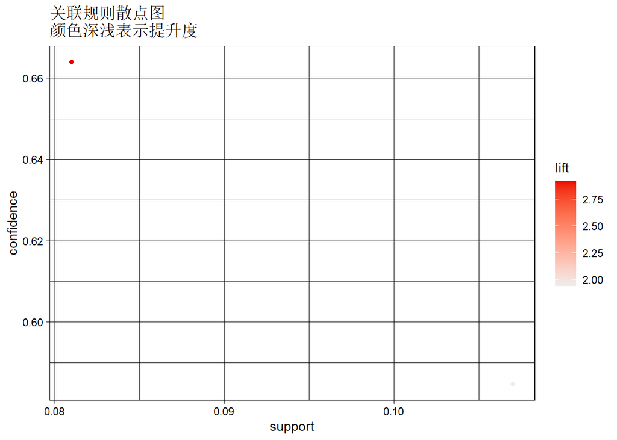

```r
library(arulesViz)

# 方法1：散点图
plot(rules, measure = c("support", "confidence"), shading = "lift",
     main = "关联规则散点图\n颜色深浅表示提升度")
```

[output not shown]

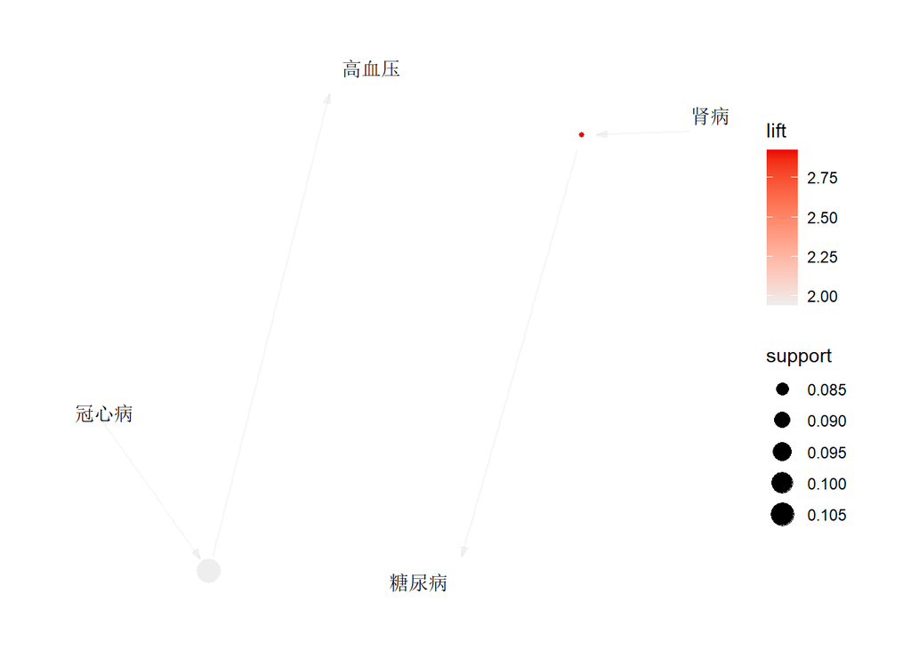

```r
# 方法2：网络图（显示规则结构）
plot(head(rules_by_lift, 20), method = "graph",
     main = "关联规则网络图（前20条）")
```

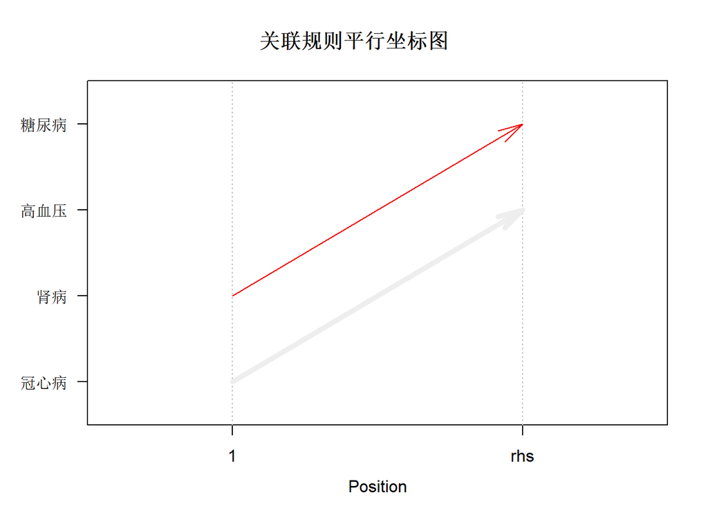

```r
# 方法3：平行坐标图
plot(head(rules_by_lift, 15), method = "paracoord",
     main = "关联规则平行坐标图")
```

### 意义与使用场景

**核心意义**：Apriori算法能够高效发现数据中的频繁模式和关联规则。

**举例**：药物相互作用发现

**为什么这种数据适合用Apriori？**

药物不良反应数据中，某些药物组合可能导致特定的不良反应。Apriori可以发现这些药物-不良反应的关联模式。

**研究目的是什么？**

1. 药物安全监测：发现潜在的药物相互作用
2. 不良反应预警：识别高风险药物组合
3. 临床决策支持：为医生用药提供参考

**可能得到什么样的结果？**

可能发现”药物A + 药物B → 不良反应C”的规则，提示这两种药物联用需要谨慎。

**需要注意什么？**

Apriori需要多次扫描数据库，对大规模数据效率较低。最小支持度和置信度的设置对结果影响很大。

## 10.3 FP-Growth算法

### 算法原理

**FP-Growth（Frequent Pattern Growth）** 是Apriori的改进算法，不需要生成候选项集：

**核心思想**：使用FP树（Frequent Pattern Tree）压缩存储数据，直接从FP树挖掘频繁项集。

**优点**： 1. 只需扫描数据库两次 2. 不生成候选项集 3. 效率比Apriori高

**缺点**： 1. FP树可能占用大量内存 2. 实现较复杂

```r
# FP-Growth在R中通过rCBA包实现
# 这里使用arules包的eclat函数作为替代（类似效果）

# 使用eclat算法挖掘频繁项集
frequent_itemsets <- arules::eclat(trans,
                                    parameter = list(
                                      support = 0.05,
                                      minlen = 2,
                                      maxlen = 4
                                    ))
```

```
## Eclat
##
## parameter specification:
##  tidLists support minlen maxlen            target  ext
##     FALSE    0.05      2      4 frequent itemsets TRUE
##
## algorithmic control:
##  sparse sort verbose
##       7   -2    TRUE
##
## Absolute minimum support count: 50
##
## create itemset ...
## set transactions ...[6 item(s), 1000 transaction(s)] done [0.00s].
## sorting and recoding items ... [6 item(s)] done [0.00s].
## creating bit matrix ... [6 row(s), 1000 column(s)] done [0.00s].
## writing  ... [7 set(s)] done [0.00s].
## Creating S4 object  ... done [0.00s].
```

```r
# 查看频繁项集
print("频繁项集：")
```

```
## [1] "频繁项集："
```

```r
arules::inspect(head(sort(frequent_itemsets, by = "support"), 10))
```

```
##     items            support count
## [1] {高血压, 冠心病} 0.107   107
## [2] {肾病, 糖尿病}   0.081    81
## [3] {高血压, 糖尿病} 0.077    77
## [4] {高血压, 高血脂} 0.076    76
## [5] {肥胖, 高血脂}   0.056    56
## [6] {肥胖, 高血压}   0.053    53
## [7] {高血脂, 糖尿病} 0.050    50
```

```r
# 从频繁项集生成规则
rules_from_fp <- arules::ruleInduction(frequent_itemsets, trans,
                                        confidence = 0.5)

# 查看生成的规则
print("从频繁项集生成的规则：")
```

```
## [1] "从频繁项集生成的规则："
```

```r
arules::inspect(head(sort(rules_from_fp, by = "lift"), 10))
```

```
##     lhs         rhs      support confidence lift     itemset
## [1] {肾病}   => {糖尿病} 0.081   0.6639344  2.924821 1
## [2] {冠心病} => {高血压} 0.107   0.5846995  1.942523 4
```

### Apriori vs FP-Growth对比

| 对比维度 | Apriori | FP-Growth |
| --- | --- | --- |
| 扫描次数 | 多次 | 2次 |
| 候选项集 | 需要生成 | 不需要 |
| 内存使用 | 较低 | 较高（FP树） |
| 适用场景 | 稀疏数据 | 密集数据 |
| 实现复杂度 | 简单 | 复杂 |

## 10.4 频繁项集挖掘

### 频繁项集的类型

| 类型 | 定义 | 示例 |
| --- | --- | --- |
| 频繁项集 | 支持度≥阈值的项集 | {高血压, 糖尿病} |
| 闭频繁项集 | 不存在超集有相同支持度 | {高血压, 糖尿病}支持度=0.1，无超集支持度=0.1 |
| 最大频繁项集 | 不存在频繁超集 | {高血压, 糖尿病, 冠心病} |

```r
# 挖掘不同类型的频繁项集

# 普通频繁项集
freq_items <- arules::eclat(trans, parameter = list(support = 0.05))
```

```
## Eclat
##
## parameter specification:
##  tidLists support minlen maxlen            target  ext
##     FALSE    0.05      1     10 frequent itemsets TRUE
##
## algorithmic control:
##  sparse sort verbose
##       7   -2    TRUE
##
## Absolute minimum support count: 50
##
## create itemset ...
## set transactions ...[6 item(s), 1000 transaction(s)] done [0.00s].
## sorting and recoding items ... [6 item(s)] done [0.00s].
## creating bit matrix ... [6 row(s), 1000 column(s)] done [0.00s].
## writing  ... [13 set(s)] done [0.00s].
## Creating S4 object  ... done [0.00s].
```

```r
print(paste("普通频繁项集数量:", length(freq_items)))
```

```
## [1] "普通频繁项集数量: 13"
```

```r
# 闭频繁项集
closed_items <- arules::eclat(trans, parameter = list(support = 0.05,
                                                       target = "closed frequent itemsets"))
```

```
## Eclat
##
## parameter specification:
##  tidLists support minlen maxlen                   target  ext
##     FALSE    0.05      1     10 closed frequent itemsets TRUE
##
## algorithmic control:
##  sparse sort verbose
##       7   -2    TRUE
##
## Absolute minimum support count: 50
##
## create itemset ...
## set transactions ...[6 item(s), 1000 transaction(s)] done [0.00s].
## sorting and recoding items ... [6 item(s)] done [0.00s].
## creating bit matrix ... [6 row(s), 1000 column(s)] done [0.00s].
## writing  ... [13 set(s)] done [0.00s].
## Creating S4 object  ... done [0.00s].
```

```r
print(paste("闭频繁项集数量:", length(closed_items)))
```

```
## [1] "闭频繁项集数量: 13"
```

```r
# 最大频繁项集
maximal_items <- arules::eclat(trans, parameter = list(support = 0.05,
                                                        target = "maximally frequent itemsets"))
```

```
## Eclat
##
## parameter specification:
##  tidLists support minlen maxlen                      target  ext
##     FALSE    0.05      1     10 maximally frequent itemsets TRUE
##
## algorithmic control:
##  sparse sort verbose
##       7   -2    TRUE
##
## Absolute minimum support count: 50
##
## create itemset ...
## set transactions ...[6 item(s), 1000 transaction(s)] done [0.00s].
## sorting and recoding items ... [6 item(s)] done [0.00s].
## creating bit matrix ... [6 row(s), 1000 column(s)] done [0.00s].
## writing  ... [7 set(s)] done [0.00s].
## Creating S4 object  ... done [0.00s].
```

```r
print(paste("最大频繁项集数量:", length(maximal_items)))
```

```
## [1] "最大频繁项集数量: 7"
```

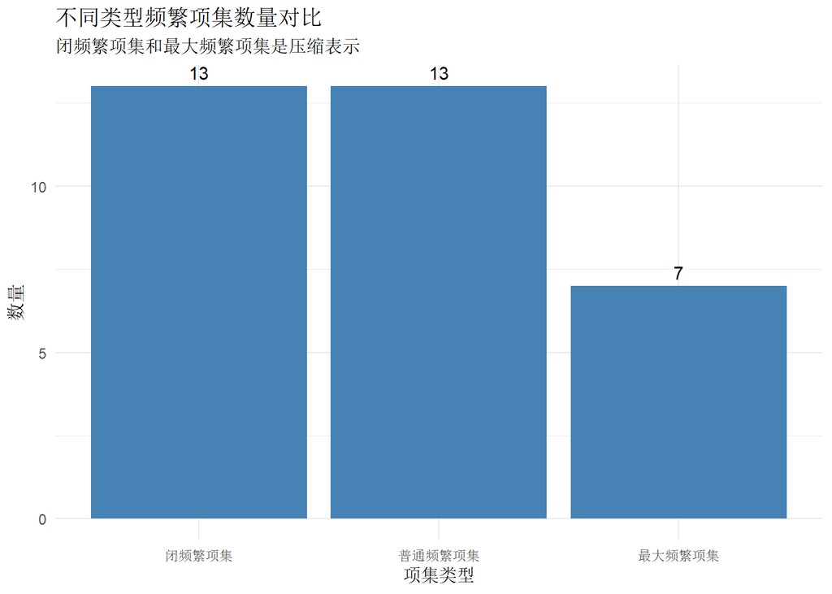

```r
# 可视化对比
itemset_counts <- data.frame(
  类型 = c("普通频繁项集", "闭频繁项集", "最大频繁项集"),
  数量 = c(length(freq_items), length(closed_items), length(maximal_items))
)

ggplot2::ggplot(itemset_counts, ggplot2::aes(x = 类型, y = 数量)) +
  ggplot2::geom_bar(stat = "identity", fill = "steelblue") +
  ggplot2::geom_text(ggplot2::aes(label = 数量), vjust = -0.5) +
  ggplot2::labs(
    title = "不同类型频繁项集数量对比",
    subtitle = "闭频繁项集和最大频繁项集是压缩表示",
    x = "项集类型", y = "数量"
  ) +
  ggplot2::theme_minimal()
```

## 10.5 序列模式挖掘基础

### 什么是序列模式？

**序列模式（Sequential Pattern）** 发现事件发生的时间顺序规律：

**示例**： - 购物序列：{牛奶} → {面包} → {鸡蛋} - 疾病发展：{高血压} → {冠心病} → {心衰}

**与关联规则的区别**： - 关联规则：发现同时出现的关系 - 序列模式：发现先后出现的关系

```r
# 序列模式挖掘示例
library(arulesSequences)

# 创建模拟的疾病发展序列数据
# 假设跟踪患者的诊断历史

set.seed(42)
n_patients_seq <- 100

# 创建序列数据框
seq_data <- data.frame(
  sequenceID = rep(1:n_patients_seq, each = 3),  # 患者ID
  eventID = rep(1:3, n_patients_seq),             # 时间点
  items = ""                                       # 诊断
)

# 生成模拟序列
for (i in 1:n_patients_seq) {
  idx <- ((i-1)*3 + 1):(i*3)

  # 时间点1：初始诊断
  initial <- sample(c("高血压", "糖尿病", "高血脂"), 1)
  seq_data$items[idx[1]] <- initial

  # 时间点2：进展（与初始诊断相关）
  if (initial == "高血压") {
    seq_data$items[idx[2]] <- sample(c("冠心病", "肾病", "无进展"), 1,
                                      prob = c(0.4, 0.2, 0.4))
  } else if (initial == "糖尿病") {
    seq_data$items[idx[2]] <- sample(c("肾病", "视网膜病变", "无进展"), 1,
                                      prob = c(0.3, 0.2, 0.5))
  } else {
    seq_data$items[idx[2]] <- sample(c("冠心病", "无进展"), 1,
                                      prob = c(0.3, 0.7))
  }

  # 时间点3：进一步进展
  seq_data$items[idx[3]] <- sample(c("心衰", "脑卒中", "终末期肾病", "稳定"), 1,
                                    prob = c(0.2, 0.2, 0.1, 0.5))
}

# 转换为transactions格式
seq_trans <- as(seq_data, "transactions")

# 查看序列数据结构
print("序列数据示例：")
```

```
## [1] "序列数据示例："
```

```r
head(seq_data, 9)
```

```
##   sequenceID eventID  items
## 1          1       1 高血压
## 2          1       2   肾病
## 3          1       3   稳定
## 4          2       1 高血压
## 5          2       2 无进展
## 6          2       3   心衰
## 7          3       1 糖尿病
## 8          3       2 无进展
## 9          3       3   心衰
```

### 序列模式挖掘

```r
# 使用cSPADE算法挖掘序列模式
# 注意：需要正确格式的数据

# 简单示例：计算序列支持度
seq_support <- seq_data %>%
  dplyr::group_by(sequenceID) %>%
  dplyr::summarise(
    seq = paste(items, collapse = " → "),
    .groups = "drop"
  )

# 统计常见序列
seq_freq <- seq_support %>%
  dplyr::count(seq, sort = TRUE)

print("最常见的疾病发展序列：")
```

```
## [1] "最常见的疾病发展序列："
```

```r
head(seq_freq, 10)
```

```
## # A tibble: 10 × 2
##    seq                          n
##    <chr>                    <int>
##  1 高血脂 → 无进展 → 稳定      13
##  2 糖尿病 → 无进展 → 稳定       8
##  3 高血压 → 冠心病 → 稳定       7
##  4 高血脂 → 无进展 → 脑卒中     6
##  5 糖尿病 → 肾病 → 稳定         5
##  6 高血压 → 肾病 → 稳定         5
##  7 糖尿病 → 无进展 → 心衰       4
##  8 糖尿病 → 肾病 → 脑卒中       4
##  9 高血压 → 无进展 → 稳定       4
## 10 高血脂 → 冠心病 → 稳定       4
```

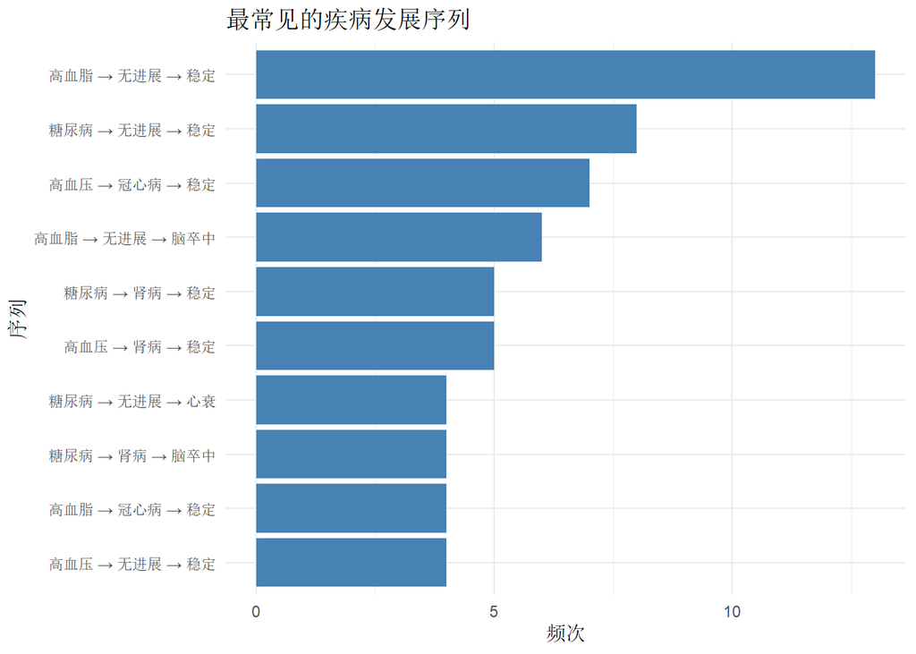

```r
# 可视化
ggplot2::ggplot(head(seq_freq, 10), ggplot2::aes(x = reorder(seq, n), y = n)) +
  ggplot2::geom_bar(stat = "identity", fill = "steelblue") +
  ggplot2::coord_flip() +
  ggplot2::labs(
    title = "最常见的疾病发展序列",
    x = "序列", y = "频次"
  ) +
  ggplot2::theme_minimal()
```

### 意义与使用场景

**核心意义**：序列模式挖掘发现事件的时间顺序规律，对疾病进展预测有重要价值。

**举例**：疾病进展轨迹分析

**为什么这种数据适合用序列模式挖掘？**

疾病发展往往遵循一定的时间顺序，如高血压→冠心病→心衰。序列模式挖掘可以发现这些进展轨迹。

**研究目的是什么？**

1. 疾病进展建模：理解疾病的发展过程
2. 早期干预：识别高风险进展路径
3. 预后预测：预测患者可能的疾病发展

**可能得到什么样的结果？**

可能发现”高血压→冠心病→心衰”是一条常见的疾病进展路径，提示需要早期干预。

**需要注意什么？**

序列数据需要准确的时间戳记录。数据质量和随访完整性对结果影响很大。

# 第十一章 特征选择与降维

## 11.1 特征选择概述

### 为什么需要特征选择？

**特征选择（Feature Selection）** 从原始特征中选择最相关的子集，目的是：

| 目的 | 说明 |
| --- | --- |
| 降低维度 | 减少计算复杂度 |
| 提高性能 | 去除噪声特征，提高模型性能 |
| 防止过拟合 | 减少特征数量，降低模型复杂度 |
| 提高可解释性 | 特征更少，模型更易理解 |

### 特征选择方法分类

| 方法类型 | 原理 | 优点 | 缺点 |
| --- | --- | --- | --- |
| 过滤法 | 基于统计指标筛选 | 快速、独立于模型 | 忽略特征间交互 |
| 包装法 | 基于模型性能筛选 | 考虑特征组合 | 计算量大 |
| 嵌入法 | 模型训练时自动选择 | 效率高 | 依赖特定模型 |

### 意义与使用场景

**核心意义**：特征选择是提高模型性能和可解释性的关键步骤。

**举例**：基因标志物筛选

**为什么这种数据适合用特征选择？**

基因表达数据通常有数千到数万个基因，但只有少数与疾病相关。特征选择可以从海量基因中筛选出真正有诊断价值的标志物。

**研究目的是什么？**

1. 标志物发现：识别与疾病相关的关键基因
2. 模型简化：减少特征数量，提高模型可解释性
3. 成本降低：减少需要检测的基因数量

**可能得到什么样的结果？**

可能从10000个基因中筛选出20个关键基因，这些基因组合可以准确预测疾病状态。

**需要注意什么？**

特征选择可能导致信息丢失，需要在模型性能和特征数量之间权衡。

## 11.2 过滤法

### 方差阈值

**原理**：删除方差过小的特征（变化不大的特征信息量小）。

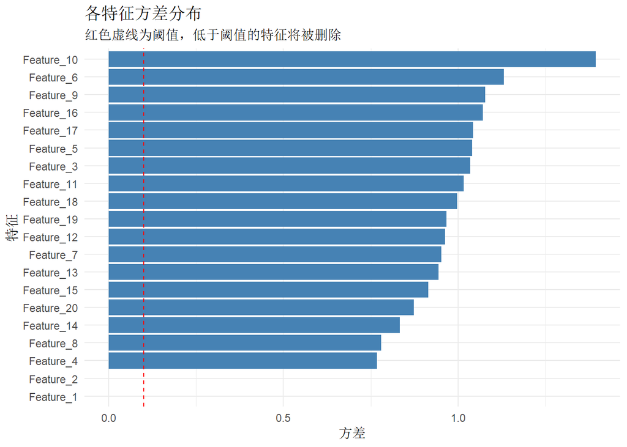

```r
# 方差阈值示例
set.seed(42)

# 创建模拟数据：100个样本，20个特征
n <- 100
p <- 20

filter_data <- matrix(rnorm(n * p), nrow = n, ncol = p)
colnames(filter_data) <- paste0("Feature_", 1:p)

# 让某些特征方差很小
filter_data[, 1] <- rnorm(n, mean = 5, sd = 0.01)  # 低方差
filter_data[, 2] <- rnorm(n, mean = 5, sd = 0.02)  # 低方差

filter_df <- as.data.frame(filter_data)

# 计算各特征的方差
variances <- apply(filter_df, 2, var)

# 创建方差数据框
var_df <- data.frame(
  Feature = names(variances),
  Variance = variances
)

# 可视化方差分布
ggplot2::ggplot(var_df, ggplot2::aes(x = reorder(Feature, Variance), y = Variance)) +
  ggplot2::geom_bar(stat = "identity", fill = "steelblue") +
  ggplot2::geom_hline(yintercept = 0.1, color = "red", linetype = "dashed") +
  ggplot2::coord_flip() +
  ggplot2::labs(
    title = "各特征方差分布",
    subtitle = "红色虚线为阈值，低于阈值的特征将被删除",
    x = "特征", y = "方差"
  ) +
  ggplot2::theme_minimal()
```

```r
# 选择方差大于阈值的特征
threshold <- 0.1
selected_features <- names(variances[variances > threshold])
print(paste("方差阈值筛选后保留的特征数:", length(selected_features)))
```

```
## [1] "方差阈值筛选后保留的特征数: 18"
```

### 相关系数

**原理**：删除与目标变量相关性低的特征。

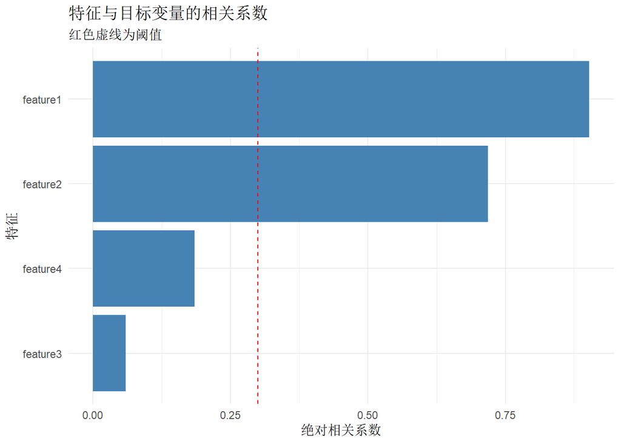

```r
# 相关系数筛选示例
set.seed(42)

# 创建带有标签的数据
n <- 100
corr_data <- data.frame(
  feature1 = rnorm(n),
  feature2 = rnorm(n),
  feature3 = rnorm(n),  # 与目标无关
  feature4 = rnorm(n),  # 与目标无关
  target = rnorm(n)
)

# 让某些特征与目标相关
corr_data$feature1 <- corr_data$target + rnorm(n, 0, 0.5)
corr_data$feature2 <- corr_data$target * 0.8 + rnorm(n, 0, 0.8)

# 计算与目标的相关系数
correlations <- sapply(corr_data[, 1:4], function(x) cor(x, corr_data$target))

# 创建相关系数数据框
cor_df <- data.frame(
  Feature = names(correlations),
  Correlation = abs(correlations)
)

# 可视化
ggplot2::ggplot(cor_df, ggplot2::aes(x = reorder(Feature, Correlation), y = Correlation)) +
  ggplot2::geom_bar(stat = "identity", fill = "steelblue") +
  ggplot2::geom_hline(yintercept = 0.3, color = "red", linetype = "dashed") +
  ggplot2::coord_flip() +
  ggplot2::labs(
    title = "特征与目标变量的相关系数",
    subtitle = "红色虚线为阈值",
    x = "特征", y = "绝对相关系数"
  ) +
  ggplot2::theme_minimal()
```

```r
print("各特征与目标的相关系数：")
```

```
## [1] "各特征与目标的相关系数："
```

```r
print(round(correlations, 3))
```

```
## feature1 feature2 feature3 feature4
##    0.902    0.718    0.059    0.185
```

### 互信息

**原理**：衡量特征与目标变量之间的信息共享量。

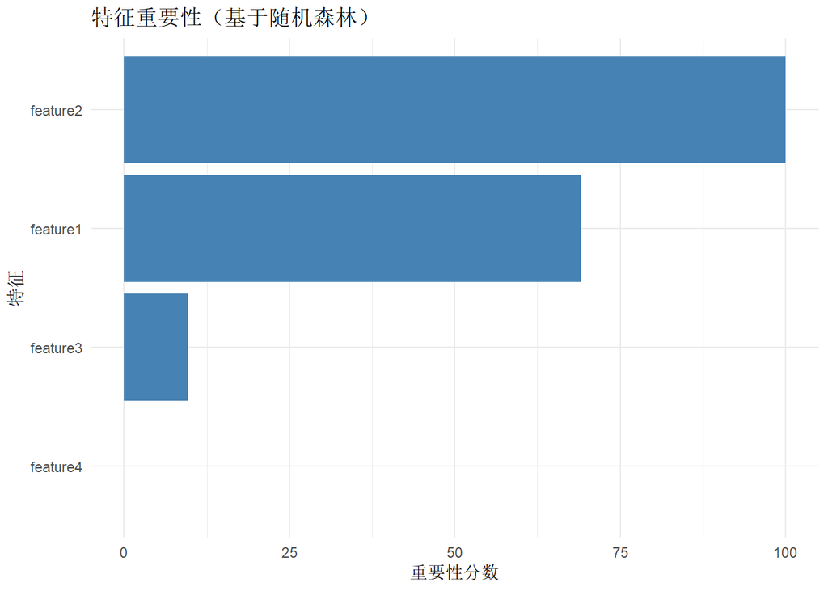

```r
# 互信息示例
# 使用caret包计算特征重要性

set.seed(42)

# 创建分类数据
n <- 200
mi_data <- data.frame(
  feature1 = c(rnorm(n/2, 0, 1), rnorm(n/2, 2, 1)),
  feature2 = c(rnorm(n/2, 0, 1), rnorm(n/2, 2, 1)),
  feature3 = rnorm(n),  # 无信息
  feature4 = rnorm(n),  # 无信息
  target = factor(rep(c("ClassA", "ClassB"), each = n/2))
)

# 使用caret计算特征重要性
# 设置训练控制
ctrl <- caret::trainControl(method = "cv", number = 5)

# 训练简单模型获取重要性
model_imp <- caret::train(target ~ ., data = mi_data,
                          method = "rf",
                          trControl = ctrl,
                          importance = TRUE,
                          ntree = 50)

# 获取特征重要性
importance_scores <- caret::varImp(model_imp)

# 可视化
ggplot2::ggplot(importance_scores, ggplot2::aes(x = reorder(rownames(importance_scores), Overall), y = Overall)) +
  ggplot2::geom_bar(stat = "identity", fill = "steelblue") +
  ggplot2::coord_flip() +
  ggplot2::labs(
    title = "特征重要性（基于随机森林）",
    x = "特征", y = "重要性分数"
  ) +
  ggplot2::theme_minimal()
```

### 卡方检验

**原理**：检验类别特征与目标变量之间的独立性。

```r
# 卡方检验示例
# 创建类别数据
set.seed(42)
n <- 200

chi_data <- data.frame(
  symptom1 = sample(c("有", "无"), n, replace = TRUE, prob = c(0.3, 0.7)),
  symptom2 = sample(c("有", "无"), n, replace = TRUE, prob = c(0.4, 0.6)),
  disease = sample(c("患病", "健康"), n, replace = TRUE, prob = c(0.2, 0.8))
)

# 让symptom1与疾病相关
chi_data$symptom1[chi_data$disease == "患病"] <- sample(c("有", "无"),
                                                         sum(chi_data$disease == "患病"),
                                                         replace = TRUE,
                                                         prob = c(0.7, 0.3))

# 计算卡方检验
chi_test1 <- chisq.test(table(chi_data$symptom1, chi_data$disease))
chi_test2 <- chisq.test(table(chi_data$symptom2, chi_data$disease))

# 汇总结果
chi_results <- data.frame(
  Feature = c("symptom1", "symptom2"),
  ChiSquare = c(chi_test1$statistic, chi_test2$statistic),
  PValue = c(chi_test1$p.value, chi_test2$p.value)
)

print("卡方检验结果：")
```

```
## [1] "卡方检验结果："
```

```r
print(chi_results)
```

```
##    Feature    ChiSquare       PValue
## 1 symptom1 23.004376576 1.616330e-06
## 2 symptom2  0.006823627 9.341654e-01
```